# SubmissionNotebook

```python
from matplotlib import pyplot as plt
from imblearn.ensemble import BalancedRandomForestClassifier
import preprocessing.utils as utils
import pandas as pd
import numpy as np
import seaborn as sns
from sklearn.metrics import plot_confusion_matrix
from sklearn.metrics import confusion_matrix
```

### This notebook is for illustration purpose. Please visit https://github.com/hym97/CAM_final_project if you want to play with the model yourself

## Classification

### Introduction

This problem is a fraud detection problem. Where the False label occupies nearly 99% of the dataset, we can simply achieve 99% accuracy by making negative predictions for all the data. But it will not help us to detect fraud. Therefore, we must do something to the dataset.

To address the problem, we can use techniques like **Undersampling**, **Oversampling**, or **Ensemble Learning**.

We used balanced random forest in this implementation.

```python
df = pd.read_csv('./data/TrainingData.csv')
X, Y = utils.pipeline(df)
Y_regression = Y.values[:,0]
Y = Y.values[:,1]
data = np.c_[X,Y]
np.random.shuffle(data)
train, validate, test = np.split(data,[int(.6 * data.shape[0]), int(.8 * data.shape[0])])
```

```python
train_X, train_Y = train[:,:-1], train[:,-1]
validate_X, validate_Y = validate[:,:-1], validate[:,-1]
test_X, test_Y = test[:,:-1], test[:,-1]
```

```python
brf = BalancedRandomForestClassifier(n_estimators=150, random_state=37)
brf.fit(train_X,train_Y)
predict_Y = brf.predict(validate_X)
```

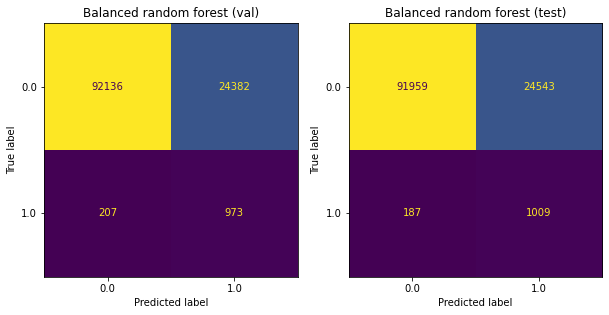

```python
fig, axs = plt.subplots(ncols=2, figsize=(10, 5))

plot_confusion_matrix(brf, validate_X, validate_Y, ax=axs[0], colorbar=False)
axs[0].set_title("Balanced random forest (val)")

plot_confusion_matrix(brf, test_X, test_Y, ax=axs[1], colorbar=False)
axs[1].set_title("Balanced random forest (test)")
plt.show()
```

#### Remarks

From the figures above, we can see many False Positive cases (24382, 24543), and the accuracy drops to 79%. However, in return, we can successfully detect fraud which is far more important than accuracy in reality.

```python
def calcualte_metrics(Y_predict, Y_labeled):
    metrics = confusion_matrix(Y_predict, Y_labeled)
    TPR = metrics[1,1] / (metrics[0,1] + metrics[1,1])
    FPR = metrics[1,0] / (metrics[0,0] + metrics[1,0])

    return TPR, FPR
```

### Calculate the metric

```python
predict_val, predict_test = brf.predict(validate_X), brf.predict(test_X)

TPR_val, FPR_val = calcualte_metrics(predict_val, validate_Y)
TPR_test, FPR_test = calcualte_metrics(predict_test, test_Y)

print("Performance on val set: TPR:{:.2f} FPR:{:.2f}".format(TPR_val,FPR_val))
print("Performance on test set: TPR:{:.2f} FPR:{:.2f}".format(TPR_test,FPR_test))
```

```
Performance on val set: TPR:0.82 FPR:0.21
Performance on test set: TPR:0.84 FPR:0.21
```

## Regression

### Introduction

This problem is simply a regression problem. But the labeled data are highly skewed. We'd better use the log transformation to make NMONTHS columns more normally distributed to get better performance.

There are many regression methods. However, considering I do not need much interoperability, I choose FFNN to make the prediction.

#### Architecture

FFNN_classifer(  
(layer1): Linear(in_features=49, out_features=64, bias=True)  
(layer2): Linear(in_features=64, out_features=128, bias=True)  
(layer3): Linear(in_features=128, out_features=10, bias=True)  
(layer4): Linear(in_features=10, out_features=1, bias=True)  
(dropout): Dropout(p=0.2, inplace=False)  
)

```python
import torch
import torch.nn as nn
import torch.nn.functional as F
import torch.optim as optim
import math
```

```python
X, Y = utils.pipeline(df)
Y_regression = Y.values[:,0]
data = np.c_[X,Y_regression]
np.random.shuffle(data)
train, validate, test = np.split(data,
                                [int(.6 * data.shape[0]), int(.8 * data.shape[0])])
```

```python
train_X, train_Y = train[:,:-1], np.log(train[:,-1])
validate_X, validate_Y = validate[:,:-1], np.log(validate[:,-1])
```

```python
class FFNN_classifer(nn.Module):
    def __init__(self, input_size):
        super(FFNN_classifer, self).__init__()
        self.layer1 = nn.Linear(input_size, 64)
        self.layer2 = nn.Linear(64, 128)
        self.layer3 = nn.Linear(128, 10)
        self.layer4 = nn.Linear(10, 1)
        self.dropout = nn.Dropout(.2)

    def forward(self, input_data):
        input_data =input_data.float()
        output = self.layer1(input_data)
        output = F.relu(output)

        output = self.layer2(output)
        output = F.relu(output)

        output = self.layer3(output)
        output = F.relu(output)
        output = self.dropout(output)

        output = self.layer4(output)

        return output
```

```python
def train_model(input_data, input_labels, optimizer, model,loss_func):
    optimizer.zero_grad()

    output = model(input_data)
    loss = loss_func(output.squeeze(1), input_labels.float())

    loss.backward()
    optimizer.step()

    return loss.item()

def mini_batch(batch_size, input_data, label):
    length = len(input_data)
    batch_num = math.ceil(length / batch_size)

    for i in range(batch_num):
        input_batch, input_label = input_data[batch_size*i:batch_size * (i + 1), :], \
                                   label[batch_size*i:batch_size * (i + 1)]
        yield input_batch, input_label


def eval_model(input_data, input_labels, model,loss_func):
    model.eval()
    input_data, input_labels = torch.tensor(input_data), torch.tensor(input_labels)
    output = model(input_data)
    loss = loss_func(output.squeeze(1), input_labels.float())

    model.train()
    return loss.item()
```

```python
epoch, N_epoch = 0, 50
batch_size = 128
model = FFNN_classifer(49)
optimizer = optim.Adam(model.parameters())
loss_func = nn.L1Loss()
while epoch < N_epoch:
    loss = 0
    for input_batch, input_label in mini_batch(batch_size, train_X, train_Y):
        input_batch, input_label = torch.tensor(input_batch), torch.tensor(input_label)
        loss = train_model(input_batch, input_label, optimizer, model, loss_func)
    if epoch % 10 == 0:
        print("epoch:{} Loss on training:{:.2f}".format(epoch, loss))
        loss_val  = eval_model(validate_X, validate_Y,model,loss_func)
        print("\tLoss on dev:{:.2f}".format(loss_val))

    epoch += 1
```

```
epoch:0 Loss on training:0.48
	Loss on dev:0.49
epoch:10 Loss on training:0.43
	Loss on dev:0.43
epoch:20 Loss on training:0.45
	Loss on dev:0.42
epoch:30 Loss on training:0.40
	Loss on dev:0.42
epoch:40 Loss on training:0.40
	Loss on dev:0.42
```

#### Remarks

We can see the loss on training set is still less than the loss on dev set even if a dropout layer is included. That may indicate we include too many parameters in the model.

### Calculate the metric

```python
test_X, test_Y = test[:,:-1], test[:,-1]

test_log_error = eval_model(test_X, np.log(test_Y),model, loss_func)

model.eval()
test_X = torch.tensor(test_X)
test_normal_error = np.abs(np.exp(model(test_X).detach().numpy()).squeeze(1) - test_Y).sum() / test_Y.shape[0]

print('On Log Scale: MAD: {:.2f}'.format(test_log_error))
print('On Normal Scale: MAD: {:.2f}'.format(test_normal_error))
```

```
On Log Scale: MAD: 0.42
On Normal Scale: MAD: 12.33
```

## Make Predictions

```python
test_data = pd.read_csv('./data/TestDataYremoved.csv')
LID = test_data.LID.values
pp_df = utils.pipeline_test(test_data)
model.eval()
```

```
FFNN_classifer(
  (layer1): Linear(in_features=49, out_features=64, bias=True)
  (layer2): Linear(in_features=64, out_features=128, bias=True)
  (layer3): Linear(in_features=128, out_features=10, bias=True)
  (layer4): Linear(in_features=10, out_features=1, bias=True)
  (dropout): Dropout(p=0.2, inplace=False)
)
```

```python
FORCLOSED = brf.predict(pp_df)
NMONTHS = np.exp(model(torch.tensor(pp_df)).detach().numpy())
```

```python
prediction = np.c_[LID, FORCLOSED, NMONTHS]
df = pd.DataFrame(prediction, columns = ['LID', 'FORCLOSED', 'NMONTHS'])
df.FORCLOSED = df.FORCLOSED.map({0:False,1:True})
df.LID = df.LID.astype('int64')
```

```python
df.head()
```

|  | LID | FORCLOSED | NMONTHS |
| --- | --- | --- | --- |
| 0 | 492709308515 | False | 15.942357 |
| 1 | 687810129762 | False | 6.862568 |
| 2 | 382328232416 | False | 24.500307 |
| 3 | 315002225730 | False | 5.486807 |
| 4 | 429983647228 | False | 21.150366 |

```python
df.to_csv('submission.csv', index = False)
```